# 2nd Assignment: Pump it Up

Ignacio Ruperez & Federico Garcia (team name Slowly). Ranking 255th. Score 0.8211

# Loading libraries

```r
library(ggplot2)
library(plyr)
library(dplyr)
library(caret)
library(e1071)
library(googleVis)
library(randomForest)
library(lubridate)
library(ranger)
library(vtreat)
library(magrittr)
library(xgboost)
library(h2o)
```

# Introduction

The main goal is to predict, by using data from Taarifa and the Tanzanian Ministry of Water, which pumps are functional, which need some repairs, and which don’t work at all

The idea is to predict one of these three classes based on a number of variables about what kind of pump is operating, when it was installed, and how it is managed. A smart understanding of which water points will fail can improve maintenance operations and ensure that clean, potable water is available to communities across Tanzania.

Vars description: https://www.drivendata.org/competitions/7/pump-it-up-data-mining-the-water-table/page/25/

# Loading datasets

```r
train = read.csv("training_set_values.csv")
test = read.csv("test_set_values.csv")
labels = read.csv("training_set_labels.csv") # dependent variable
```

We combine train and test datasets into one total dataset

```r
total <- rbind(train, test)
```

# Feature engineering process

Here we analyze every feature in the dataset and perform different actions: combination of features, elimination, imputation and creation of new features.

## id

They are unique identifiers, so we can delete the column

```r
total <- within(total, rm('id'))
```

## amount_tsh: Total static head (amount water available to waterpoint)

We can make 4 groups: zero, low, medium and high

```r
total$amount_tsh_group <- cut(total$amount_tsh, breaks = c(-Inf, 0, 100, 1000, Inf), labels = c("zero", "low", "medium", "high"))
```

## construction_year: Year the waterpoint was constructed

```r
table(total$construction_year)
```

```
##
##     0  1960  1961  1962  1963  1964  1965  1966  1967  1968  1969  1970
## 25969   124    28    36   107    48    21    19   106    93    77   493
##  1971  1972  1973  1974  1975  1976  1977  1978  1979  1980  1981  1982
##   177   892   227   814   561   525   247  1267   245  1005   291   926
##  1983  1984  1985  1986  1987  1988  1989  1990  1991  1992  1993  1994
##   594   970  1177   553   370   657   396  1176   407   807   745   940
##  1995  1996  1997  1998  1999  2000  2001  2002  2003  2004  2005  2006
##  1283  1020   821  1190  1222  2578   680  1343  1579  1417  1275  1892
##  2007  2008  2009  2010  2011  2012  2013
##  1960  3243  3196  3314  1591  1347   209
```

We can calculate the number of years the well has:

```r
total <- total %>%
  mutate(date_recorded = ymd(date_recorded)) %>%
  mutate(operation_years = lubridate::year(date_recorded) - construction_year) %>%
  mutate(operation_years = ifelse(operation_years < 0 | operation_years > 2000, -1, operation_years))
```

We can also create a new feature: top20_construction_year (this will be made for several features in order to reduce the number of levels)

```r
total$top20_construction_year <- factor(paste0("y",as.character(total$construction_year)))
years <- names(summary(total$top20_construction_year)[order(-summary(total$top20_construction_year))][1:20])
lyears <- factor(total$top20_construction_year, levels=c(years, "Other"))
lyears[is.na(lyears)] <- "Other"
total$top20_construction_year <- lyears
```

## date_recorded: The date the row was entered

We can extract the month from this feature, as Tanzania has dry months and rainy months.

```r
total <- total %>%
  mutate(month_recorded = lubridate::month(date_recorded))
```

We can then delete date_recorded, as it is not informative per se.

```r
total <- within(total, rm('date_recorded'))
```

## funder: Who funded the well

We can make 3 groups: government, unknown and other

```r
total$funder_group <- ifelse(total$funder == "" | total$funder == "0", "unknown", ifelse(grepl("gov",total$funder, ignore.case = TRUE), "government", "other"))
total$funder_group <- as.factor(total$funder_group)

levels(total$funder) <- c(levels(total$funder), "unknown")
total$funder[total$funder == ""]  <- "unknown"
total$funder[total$funder == "0"]  <- "unknown"
total$funder <- factor(total$funder)
```

We can also create another feature: top20_funders

```r
total$top20_funders <- factor(total$funder)
funders <- names(summary(total$top20_funders)[order(-summary(total$top20_funders))][1:20])
lfunders <- factor(total$top20_funders, levels=c(funders, "Other"))
lfunders[is.na(lfunders)] <- "Other"
total$top20_funders <- lfunders
```

## installer: Organization that installed the well

We can make 3 groups: government, unknown and other

```r
levels(total$installer) <- tolower(levels(total$installer))

total$installer_group <- ifelse(total$installer == "" | total$installer == "0" | total$installer == "-", "unknown", ifelse(grepl("gov",total$installer, ignore.case = TRUE), "government", "other"))
total$installer_group <- as.factor(total$installer_group)

levels(total$installer) <- c(levels(total$installer), "unknown")
total$installer[total$installer == ""]  <- "unknown"
total$installer[total$installer == "0"]  <- "unknown"
total$installer[total$installer == "-"]  <- "unknown"
total$installer <- factor(total$installer)
```

We can also create another feature: top20_installers

```r
total$top20_installers <- factor(total$installer)
installers <- names(summary(total$top20_installers)[order(-summary(total$top20_installers))][1:20])
linstallers <- factor(total$top20_installers, levels=c(installers, "Other"))
linstallers[is.na(linstallers)] <- "Other"
total$top20_installers <- linstallers
```

## wpt_name: Name of the waterpoint if there is one

```r
unique(total$wpt_name)

# There are 45684 different names, so we delete this feature

total <- within(total, rm('wpt_name'))
```

## num_private: -

There is no information about this feature. They are integer numbers from 0 to 1776. We can make 2 groups: zero and other

```r
total$num_private_group <- ifelse(total$num_private == 0, "zero", "other")
total$num_private_group <- as.factor(total$num_private_group)
```

## basin: Geographic water basin

```r
table(total$basin)
```

```
##
##                Internal              Lake Nyasa              Lake Rukwa
##                    9642                    6332                    3059
##         Lake Tanganyika           Lake Victoria                 Pangani
##                    8052                   12871                   11143
##                  Rufiji Ruvuma / Southern Coast             Wami / Ruvu
##                    9987                    5587                    7577
```

We have 9 levels for this feature and no null values, so we leave as it is.

## subvillage: Geographic location

There are 470 blank values. We set them to unknown.

```r
levels(total$subvillage) <- c(levels(total$subvillage), "unknown")
total$subvillage[total$subvillage == ""]  <- "unknown"
total$subvillage <- factor(total$subvillage)
```

We can create another feature: top20_subvillages

```r
total$top20_subvillages <- factor(total$subvillage)
subvillages <- names(summary(total$top20_subvillages)[order(-summary(total$top20_subvillages))][1:20])
lsubvillages <- factor(total$top20_subvillages, levels=c(subvillages, "Other"))
lsubvillages[is.na(lsubvillages)] <- "Other"
total$top20_subvillages <- lsubvillages
```

## region: Geographic location

```r
table(total$region)
```

```
##
##        Arusha Dar es Salaam        Dodoma        Iringa        Kagera
##          4111          1020          2779          6599          4174
##        Kigoma   Kilimanjaro         Lindi       Manyara          Mara
##          3533          5494          1920          1972          2451
##         Mbeya      Morogoro        Mtwara        Mwanza         Pwani
##          5758          5038          2144          3897          3331
##         Rukwa        Ruvuma     Shinyanga       Singida        Tabora
##          2242          3306          6293          2536          2466
##         Tanga
##          3186
```

We have 21 levels for this feature and no null values, so we leave as it is.

## region_code: Geographic location (coded)

```r
table(total$region_code, total$region)
```

```
##
##      Arusha Dar es Salaam Dodoma Iringa Kagera Kigoma Kilimanjaro Lindi
##   1       0             0   2779      0      0      0           0     0
##   2    3709             0      0      0      0      0           0     0
##   3       0             0      0      0      0      0        5494     0
##   4       0             0      0      0      0      0           0     0
##   5       0             0      0      0      0      0           0     0
##   6       0             0      0      0      0      0           0     0
##   7       0          1020      0      0      0      0           0     0
##   8       0             0      0      0      0      0           0   375
##   9       0             0      0      0      0      0           0     0
##   10      0             0      0      0      0      0           0     0
##   11      0             0      0   6599      0      0           0     0
##   12      0             0      0      0      0      0           0     0
##   13      0             0      0      0      0      0           0     0
```

[output cut: 72 more lines]

There are some regions with more than one code, and some codes with more than one region, so we remove this feature.

```r
total <- within(total, rm('region_code'))
```

## district_code: Geographic location (coded)

```r
table(total$region, total$district_code)
```

```
##
##                    0    1    2    3    4    5    6    7    8   13   23
##   Arusha           0  226 1460  143    0  245  391 1244    0    0    0
##   Dar es Salaam    0  121  633  266    0    0    0    0    0    0    0
##   Dodoma          27 1107    0  460  439  467  279    0    0    0    0
##   Iringa           0  914  659  815 3090  687    0  434    0    0    0
##   Kagera           0  967  622  505  501    0  112  325  288    0    0
##   Kigoma           0 1101 1458  897   77    0    0    0    0    0    0
##   Kilimanjaro      0  752  642 1106 1536  775  134  549    0    0    0
##   Lindi            0    1    8  375    0    0    0    0    0  496  360
##   Manyara          0  664  344  385  335  244    0    0    0    0    0
##   Mara             0  215  905  480  533    0  318    0    0    0    0
##   Mbeya            0  365  605 1087 1381  253 1286  781    0    0    0
##   Morogoro         0 1368  656 1259  789  120  846    0    0    0    0
##   Mtwara           0  512    0    0  346  153    0    0    0    0    0
##   Mwanza           0  514  937   87  761  410  603  428  157    0    0
##   Pwani            0 1247  396  126  228    0   35    0    0    0    0
##   Rukwa            0  852  641  528  221    0    0    0    0    0    0
##   Ruvuma           0  539  821  943  158  845    0    0    0    0    0
##   Shinyanga        0 1508 1015 1787   27  653  565  235  490    0    0
##   Singida          0  680 1202  446  208    0    0    0    0    0    0
##   Tabora           0  729  420  415  489  215  198    0    0    0    0
##   Tanga            0  917  505  411  134  361  341  170  347    0    0
##
##                   30   33   43   53   60   62   63   67   80
##   Arusha         402    0    0    0    0    0    0    0    0
##   Dar es Salaam    0    0    0    0    0    0    0    0    0
##   Dodoma           0    0    0    0    0    0    0    0    0
##   Iringa           0    0    0    0    0    0    0    0    0
##   Kagera         854    0    0    0    0    0    0    0    0
##   Kigoma           0    0    0    0    0    0    0    0    0
##   Kilimanjaro      0    0    0    0    0    0    0    0    0
##   Lindi            0    0  205  348    0  127    0    0    0
##   Manyara          0    0    0    0    0    0    0    0    0
##   Mara             0    0    0    0    0    0    0    0    0
##   Mbeya            0    0    0    0    0    0    0    0    0
##   Morogoro         0    0    0    0    0    0    0    0    0
##   Mtwara           0  920    0    0    0    0  213    0    0
##   Mwanza           0    0    0    0    0    0    0    0    0
##   Pwani            0  143  448  573   76    0   51    8    0
##   Rukwa            0    0    0    0    0    0    0    0    0
##   Ruvuma           0    0    0    0    0    0    0    0    0
##   Shinyanga        0    0    0    0    0    0    0    0   13
##   Singida          0    0    0    0    0    0    0    0    0
##   Tabora           0    0    0    0    0    0    0    0    0
##   Tanga            0    0    0    0    0    0    0    0    0
```

The distric_code only makes sense if it’s attached to the region name (one code is shared among several regions), so we create a column for both features together:

```r
district <- paste(total$region, total$district_code, sep = "_")
total$district <- district
total$district <- as.factor(total$district)
```

We can also create another feature: top20_districts:

```r
total$top20_districts <- factor(total$district)
districts <- names(summary(total$top20_districts)[order(-summary(total$top20_districts))][1:20])
ldistricts <- factor(total$top20_districts, levels=c(districts, "Other"))
ldistricts[is.na(ldistricts)] <- "Other"
total$top20_districts <- ldistricts
```

## longitude and latitude: GPS coordinates

Let’s check if all the coordinates are inside the country of Tanzania

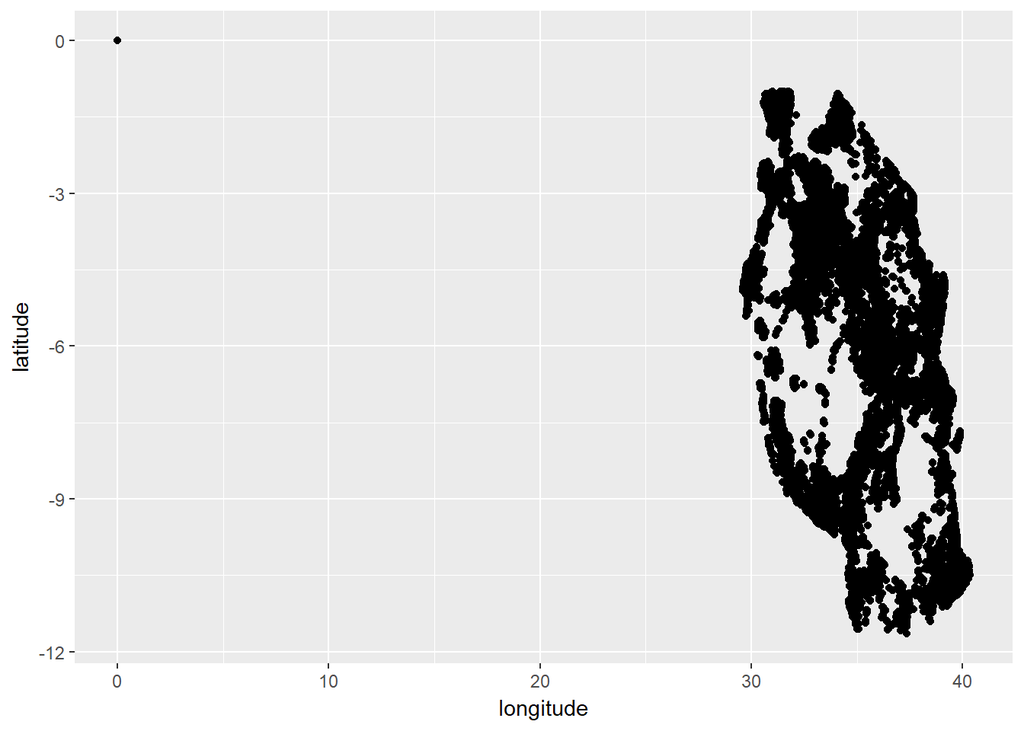

```r
ggplot(total,
    aes(x = longitude, y = latitude)) +
    geom_point(shape = 16) +
    theme(legend.position = "top")
```

There are several points with (0,0) coordinates. If we filter them, we can obtain a better plot:

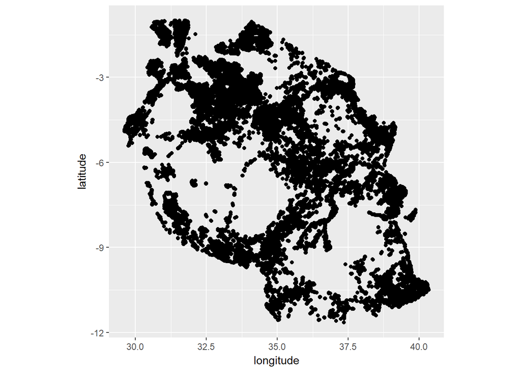

```r
ggplot(subset(total, longitude > 0.1 & latitude < -0.1),
    aes(x = longitude, y = latitude)) +
    geom_point(shape = 16) +
    theme(legend.position = "top") +
    coord_fixed()
```

We can impute (0,0) coordinates with the average coordinates for the same district:

```r
total <- total %>%
  mutate(latitude = ifelse(latitude > -0.1, NA, latitude)) %>%
  mutate(longitude = ifelse(longitude < 0.1, NA, longitude))

total <- total %>%
  group_by(district) %>%
  mutate(district_long = mean(longitude, na.rm = TRUE)) %>%
  mutate(district_lat = mean(latitude, na.rm = TRUE)) %>%
  ungroup()

total <- total %>%
  group_by(region) %>%
  mutate(region_long = mean(longitude, na.rm = TRUE)) %>%
  mutate(region_lat = mean(latitude, na.rm = TRUE)) %>%
  ungroup()

total <- total %>%
  mutate(longitude = ifelse(!is.na(longitude), longitude, ifelse(!is.na(district_long), district_long, region_long))) %>%
  mutate(latitude = ifelse(!is.na(latitude), latitude, ifelse(!is.na(district_lat), district_lat, region_lat)))
```

Besides, we can divide the map in a grid of 20x20 and assign each coordinate to its corresponding area.

```r
maxlong <- max(total$longitude)
minlong <- min(total$longitude[which(total$longitude > 0.1)])
maxlat <- max(total$latitude[which(total$latitude < -0.1)])
minlat <- min(total$latitude)

gridlong <- cut(total$longitude, breaks = seq(minlong, maxlong, (maxlong-minlong)/20), labels = LETTERS[seq( from = 1, to = 20 )])
gridlong2 <- addNA(gridlong)
levels(gridlong2) <- c(levels(gridlong), "X")

gridlat <- cut(total$latitude, breaks = seq(minlat, maxlat, (maxlat-minlat)/20), labels = LETTERS[seq( from = 1, to = 20 )])
gridlat2 <- addNA(gridlat)
levels(gridlat2) <- c(levels(gridlat), "X")

gridcoor <- paste0(gridlat2, gridlong2)
total$gridcoor <- gridcoor
total$gridcoor <- as.factor(total$gridcoor)
```

We can create another feature: top20_gridcoors

```r
total$top20_gridcoors <- factor(total$gridcoor)
gridcoors <- names(summary(total$top20_gridcoors)[order(-summary(total$top20_gridcoors))][1:20])
lgridcoors <- factor(total$top20_gridcoors, levels=c(gridcoors, "Other"))
lgridcoors[is.na(lgridcoors)] <- "Other"
total$top20_gridcoors <- lgridcoors
```

## gps_height: Altitude of the well

There are lots of missing values in this feature. We think that just imputing the mean or median from the same region is not a good idea, as a single region can have very high and very low areas.

To check if gps_heights are correctly stored in the dataset and to impute blank heights, we have used the Google Elevation API: https://developers.google.com/maps/documentation/elevation/start

```r
altitudes <- vector()

for(i in 1:length(total$longitude)){
  altitude <- elevation(latlong=list(c(total$latitude[i],total$longitude[i])), key = "YourAPIKey")
  altitudes <- c(altitudes, altitude$elevation)
}

write.table(altitudes, file="altitudes.csv", row.names = FALSE, col.names = FALSE)
```

[figure not shown]

Google Elevation API

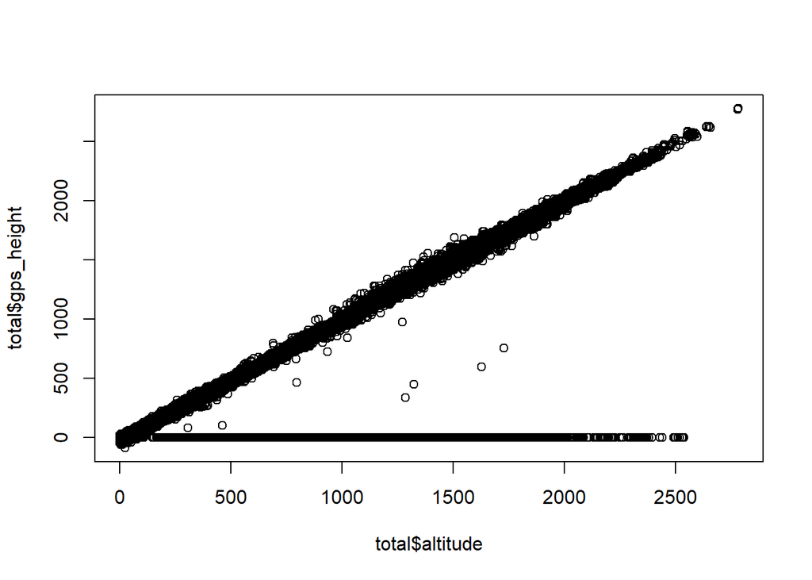

```r
altitude <- read.csv("altitudes.csv", header = FALSE, check.names = FALSE) # obtained from Google Elevation API

total$altitude <- altitude$V1

# We can plot our altitudes from Google with gps_height to see the difference

plot(total$altitude, total$gps_height)
```

We can see that there are some incorrect heights in the dataset, as well as plenty of NAs, so adding calculated altitudes from Google Elevation API have solved this problem.

## lga: Geographic location

```r
table(total$lga)
```

```
##
##     Arusha Rural     Arusha Urban           Babati         Bagamoyo
##             1521               82              618             1263
##             Bahi          Bariadi       Biharamulo     Bukoba Rural
##              279             1485              501              622
##     Bukoba Urban          Bukombe            Bunda         Chamwino
##              112              653              533              439
##            Chato           Chunya     Dodoma Urban            Geita
##              288              365              467              603
##              Hai           Hanang          Handeni           Igunga
##              780              344              327              419
##            Ilala            Ileje          Ilemela           Iramba
##              633              288              175              680
##     Iringa Rural           Kahama          Karagwe           Karatu
##              914             1058              967              402
##           Kasulu           Kibaha          Kibondo     Kigoma Rural
##             1322              358             1101             1015
##     Kigoma Urban          Kilindi           Kilolo        Kilombero
##               95              211              434             1207
##           Kilosa            Kilwa        Kinondoni         Kisarawe
##             1368              497              121              269
##          Kishapu           Kiteto           Kondoa           Kongwa
##              503              253              644              460
##          Korogwe           Kwimba            Kyela      Lindi Rural
##              511              788             1070              471
##      Lindi Urban           Liwale          Longido           Ludewa
##               24              205              391              687
##          Lushoto            Mafia             Magu           Makete
##              870              170             1049              789
##          Manyoni           Masasi            Maswa          Mbarali
##              446              649             1024              781
##      Mbeya Rural           Mbinga            Mbozi            Mbulu
##              587              943             1286              385
##            Meatu             Meru          Misenyi        Missungwi
##              584             1244              325              427
##           Mkinga         Mkuranga          Monduli   Morogoro Rural
##              347              698              226              656
##   Morogoro Urban      Moshi Rural      Moshi Urban           Mpanda
##              120             1566              103              852
##          Mpwapwa     Mtwara Rural     Mtwara Urban          Mufindi
```

[output cut: 10 more lines]

```
##              747              269              348              573
##           Rungwe             Same        Sengerema        Serengeti
##             1381             1106              411              905
##  Shinyanga Rural  Shinyanga Urban             Siha          Sikonge
##              751              235              550              215
##        Simanjiro    Singida Rural    Singida Urban     Songea Rural
##              372             1202              208              876
##     Songea Urban Sumbawanga Rural Sumbawanga Urban     Tabora Urban
##              103              641              221              195
##       Tandahimba            Tanga           Tarime           Temeke
##              346              121              264              266
##          Tunduru          Ukerewe           Ulanga           Urambo
##              539              442              841              489
##             Uyui
##              418
```

We can make 3 groups: urban, rural and other:

```r
total$lga_group <- ifelse(grepl("urban", total$lga, ignore.case = TRUE), "urban", ifelse(grepl("rural", total$lga, ignore.case = TRUE), "rural", "other"))
total$lga_group <- as.factor(total$lga_group)
```

We can also create another feature: top20_lgas

```r
total$top20_lgas <- factor(total$lga)
lgas <- names(summary(total$top20_lgas)[order(-summary(total$top20_lgas))][1:20])
llgas <- factor(total$top20_lgas, levels=c(lgas, "Other"))
llgas[is.na(llgas)] <- "Other"
total$top20_lgas <- llgas
```

## ward: Geographic location

```r
table(total$ward)
```

We can create another feature: top20_wards

```r
total$top20_wards <- factor(total$ward)
wards <- names(summary(total$top20_wards)[order(-summary(total$top20_wards))][1:20])
lwards <- factor(total$top20_wards, levels=c(wards, "Other"))
lwards[is.na(lwards)] <- "Other"
total$top20_wards <- lwards
```

## population: Population around the well

We can make 2 groups: zero or non-zero

```r
total$population_group <- ifelse(total$population == 0, "zero", "non-zero")
total$population_group <- as.factor(total$population_group)
```

## public_meeting: True/False

We fill NA values with “unknown”

```r
levels(total$public_meeting) <- c(levels(total$public_meeting), "unknown")
total$public_meeting[total$public_meeting == ""]  <- "unknown"
total$public_meeting <- factor(total$public_meeting)
```

## recorded_by: Group entering this row of data

```r
table(total$recorded_by)
```

```
##
## GeoData Consultants Ltd
##                   74250
```

Only one value, so we remove the feature:

```r
total <- within(total, rm('recorded_by'))
```

## scheme_management: Who operates the waterpoint

We fill NA values with “unknown”

```r
levels(total$scheme_management) <- c(levels(total$scheme_management), "unknown")
total$scheme_management[total$scheme_management == ""]  <- "unknown"
total$scheme_management <- factor(total$scheme_management)
```

## scheme_name: Who operates the waterpoint

```r
levels(total$scheme_name) <- tolower(levels(total$scheme_name))

total$scheme_name_group <- ifelse(total$scheme_name == "", "unknown", ifelse(grepl("gov",total$scheme_name, ignore.case = TRUE), "government", ifelse(total$scheme_name == "None", "none", "other")))
total$scheme_name_group <- as.factor(total$scheme_name_group)

levels(total$scheme_name) <- c(levels(total$scheme_name), "unknown")
total$scheme_name[total$scheme_name == ""]  <- "unknown"
total$scheme_name <- factor(total$scheme_name)
```

We can create another feature: top20_scheme_names

```r
total$top20_scheme_names <- factor(total$scheme_name)
scheme_names <- names(summary(total$top20_scheme_names)[order(-summary(total$top20_scheme_names))][1:20])
lscheme_names <- factor(total$top20_scheme_names, levels=c(scheme_names, "Other"))
lscheme_names[is.na(lscheme_names)] <- "Other"
total$top20_scheme_names <- lscheme_names
```

## permit: If the waterpoint is permitted

We fill NA values with “unknown”

```r
levels(total$permit) <- c(levels(total$permit), "unknown")
total$permit[total$permit == ""]  <- "unknown"
total$permit <- factor(total$permit)
```

## extraction_type: The kind of extraction the waterpoint uses

```r
table(total$extraction_type)
```

```
##
##                   afridev                      cemo
##                      2208                       108
##                    climax                   gravity
##                        41                     33263
##             india mark ii            india mark iii
##                      3029                       135
##                       ksb                      mono
##                      1790                      3628
##               nira/tanira                     other
##                     10205                      8102
## other - mkulima/shinyanga         other - play pump
##                         2                       101
##         other - rope pump            other - swn 81
##                       572                       284
##               submersible                    swn 80
##                      5982                      4588
##                    walimi                  windmill
##                        60                       152
```

We leave it as it is

## extraction_type_group: The kind of extraction the waterpoint uses

```r
table(total$extraction_type_group)
```

```
##
##         afridev         gravity   india mark ii  india mark iii
##            2208           33263            3029             135
##            mono     nira/tanira           other  other handpump
##            3628           10205            8102             447
## other motorpump       rope pump     submersible          swn 80
##             149             572            7772            4588
##    wind-powered
##             152
```

It is very similar to the previous feature, but we leave it in case the slight differences are significant.

## extraction_type_class: The kind of extraction the waterpoint uses

```r
table(total$extraction_type_class)
```

```
##
##      gravity     handpump    motorpump        other    rope pump
##        33263        20612         3777         8102          572
##  submersible wind-powered
##         7772          152
```

We leave as it is.

## management: How the waterpoint is managed

```r
table(total$management)
```

```
##
##          company            other   other - school       parastatal
##              859             1083              126             2229
## private operator            trust          unknown              vwc
##             2504              105              683            50624
##  water authority      water board              wua              wug
##             1123             3688             3118             8108
```

We leave it as it is.

## management_group: How the waterpoint is managed

```r
table(total$management_group)
```

```
##
## commercial      other parastatal    unknown user-group
##       4591       1209       2229        683      65538
```

We leave it as it is.

## payment: What the water costs

```r
table(total$payment)
```

```
##
##             never pay                 other          pay annually
##                 31712                  1314                  4570
##           pay monthly        pay per bucket pay when scheme fails
##                 10397                 11266                  4842
##               unknown
##                 10149
```

We leave it as it is.

## payment_type: What the water costs

```r
table(total$payment_type)
```

```
##
##   annually    monthly  never pay on failure      other per bucket
##       4570      10397      31712       4842       1314      11266
##    unknown
##      10149
```

It is the same data as the previuos feature. We can remove “payment”:

```r
total <- within(total, rm('payment'))
```

## water_quality: The quality of the water

```r
table(total$water_quality)
```

```
##
##           coloured           fluoride fluoride abandoned
##                623                244                 23
##              milky              salty    salty abandoned
##               1005               6082                423
##               soft            unknown
##              63505               2345
```

We leave it as it is.

## quality_group: The quality of the water

```r
table(total$quality_group)
```

```
##
##  colored fluoride     good    milky    salty  unknown
##      623      267    63505     1005     6505     2345
```

We leave it as it is.

## quantity: The quantity of water

```r
table(total$quantity)
```

```
##
##          dry       enough insufficient     seasonal      unknown
##         7782        41522        18896         5075          975
```

We leave it as it is.

## quantity_group: The quantity of water

```r
table(total$quantity_group)
```

```
##
##          dry       enough insufficient     seasonal      unknown
##         7782        41522        18896         5075          975
```

It is the same data as the previuos feature. We can remove “quantity_group”:

```r
total <- within(total, rm('quantity_group'))
```

## source: The source of the water

```r
table(total$source)
```

```
##
##                  dam             hand dtw                 lake
##                  840                 1108                  950
##          machine dbh                other rainwater harvesting
##                13822                  261                 2863
##                river         shallow well               spring
##                11964                21140                21216
##              unknown
##                   86
```

We leave it as it is

## source_type: The source of the water

```r
table(total$source_type)
```

```
##
##             borehole                  dam                other
##                14930                  840                  347
## rainwater harvesting           river/lake         shallow well
##                 2863                12914                21140
##               spring
##                21216
```

We leave it as it is

## source_class: The source of the water

```r
table(total$source_class)
```

```
##
## groundwater     surface     unknown
##       57286       16617         347
```

We leave it as it is

## waterpoint_type: The kind of waterpoint

```r
table(total$waterpoint_type)
```

```
##
##               cattle trough          communal standpipe
##                         150                       35628
## communal standpipe multiple                         dam
##                        7611                           8
##                   hand pump             improved spring
##                       21884                         959
##                       other
##                        8010
```

We leave it as it is

## waterpoint_type_group: The kind of waterpoint

```r
table(total$waterpoint_type_group)
```

```
##
##      cattle trough communal standpipe                dam
##                150              43239                  8
##          hand pump    improved spring              other
##              21884                959               8010
```

We leave it as it is

## Removing useless generated features

```r
total <- within(total, rm('district_long'))
total <- within(total, rm('district_lat'))
total <- within(total, rm('region_long'))
total <- within(total, rm('region_lat'))
```

# Training and test separation

```r
training_data = cbind(total[1:59400,], labels["status_group"])
test_data = cbind(test["id"], total[59401:74250,])
```

# Models

Here we run several models to check which one performs better

## Random Forest

First, we run the basic Random Forest algorithm with all the features and a few trees to see which features are not important and remove them.

```r
set.seed(42)

model_forest <- randomForest(as.factor(status_group) ~ amount_tsh + top20_funders + gps_height + top20_installers + longitude + latitude + num_private + basin + top20_subvillages + region + district_code + top20_lgas + top20_wards + population + public_meeting + scheme_management + top20_scheme_names + permit + construction_year + extraction_type + extraction_type_group + extraction_type_class + management + management_group + payment_type + water_quality + quality_group + quantity + source + source_type + source_class + waterpoint_type + waterpoint_type_group + amount_tsh_group + operation_years + top20_construction_year + month_recorded + funder_group + installer_group + num_private_group + top20_districts + top20_gridcoors + altitude + lga_group + population_group + scheme_name_group, data = training_data, na.action=na.omit, importance = TRUE, ntree = 5, nodesize = 1)

pred_forest_train <- predict(model_forest, training_data)

confusionMatrix(pred_forest_train, training_data$status_group)
```

```
## Confusion Matrix and Statistics
##
##                          Reference
## Prediction                functional functional needs repair
##   functional                   31063                    1211
##   functional needs repair        326                    2855
##   non functional                 870                     251
##                          Reference
## Prediction                non functional
##   functional                        1980
##   functional needs repair            208
##   non functional                   20636
##
## Overall Statistics
##
##                Accuracy : 0.9184
##                  95% CI : (0.9162, 0.9206)
##     No Information Rate : 0.5431
##     P-Value [Acc > NIR] : < 2.2e-16
##
##                   Kappa : 0.8495
##  Mcnemar's Test P-Value : < 2.2e-16
##
## Statistics by Class:
##
##                      Class: functional Class: functional needs repair
## Sensitivity                     0.9629                        0.66134
## Specificity                     0.8824                        0.99031
## Pos Pred Value                  0.9068                        0.84243
## Neg Pred Value                  0.9524                        0.97390
## Prevalence                      0.5431                        0.07268
## Detection Rate                  0.5229                        0.04806
## Detection Prevalence            0.5767                        0.05705
## Balanced Accuracy               0.9227                        0.82582
##                      Class: non functional
## Sensitivity                         0.9041
## Specificity                         0.9694
## Pos Pred Value                      0.9485
## Neg Pred Value                      0.9419
## Prevalence                          0.3842
## Detection Rate                      0.3474
## Detection Prevalence                0.3663
## Balanced Accuracy                   0.9367
```

```r
randomForest::importance(model_forest)
```

```
##                         functional functional needs repair non functional
## amount_tsh                4.157709                1.404162      0.9164747
## top20_funders             7.047088                7.243810      6.8270592
## gps_height               11.869251                1.845630     24.8026765
## top20_installers         13.191878                3.601410      5.7641076
## longitude                22.234543                6.511918      9.8457582
## latitude                  8.957558                8.468591     10.6452248
## num_private               1.734090               -1.118034      1.5644635
## basin                    12.283627                4.766095     10.8219705
## top20_subvillages         1.455505                5.623403      6.3345165
## region                    8.405409                4.695878      9.6385932
## district_code             3.862760                5.525509      6.3012278
## top20_lgas                3.754747                4.502039     13.0063019
## top20_wards               1.983243                5.402360      0.9779647
## population               11.054725                3.858395      7.3262191
## public_meeting           13.533557                2.215020      9.0731249
## scheme_management        10.803791                4.712094     11.2225044
## top20_scheme_names       20.811158                1.682911      6.3404873
## permit                    9.351302                2.198892      3.0532397
## construction_year         9.609951                2.731423      7.4115588
## extraction_type           9.364546                4.374457      3.5128105
## extraction_type_group     3.586964                6.651488      2.6154227
## extraction_type_class     2.976722                3.136800      3.0603328
## management                7.503943                3.761436      4.7538837
## management_group         21.466068                2.449579      4.0571023
## payment_type              4.319867                5.769895      4.8689192
## water_quality             6.030307                1.364643      3.3071490
## quality_group             5.894466                2.899827      4.9769672
## quantity                 14.028945                4.992342     21.2249165
## source                    6.991895                5.666035      4.3836360
## source_type               4.792347                8.440252      4.1908345
## source_class              2.566552                3.092228      2.7200712
## waterpoint_type           3.125845                3.254690      2.4353026
## waterpoint_type_group     3.495706                2.617274      2.4599978
## amount_tsh_group          4.166791                3.948586      5.3461818
## operation_years           6.785041                5.025962      4.1081098
## top20_construction_year   7.200146                5.705850      6.5960042
## month_recorded            8.025619                7.788668      8.3386328
## funder_group              3.745784                2.323307      3.8953902
## installer_group           1.914756                7.058193      4.1363392
```

[output cut: 39 more lines]

```
## waterpoint_type                     2.954044       1026.90494
## waterpoint_type_group               2.982645        866.14853
## amount_tsh_group                    4.541253       1033.04076
## operation_years                     6.506441        785.91229
## top20_construction_year             8.233892       1071.53566
## month_recorded                     10.736322        492.37499
## funder_group                        5.077348        125.38584
## installer_group                     3.534154        135.87972
## num_private_group                   1.249389         10.46910
## top20_districts                    12.732395        394.00018
## top20_gridcoors                     5.556243        413.75873
## altitude                           12.792484       1764.20607
## lga_group                           6.923700         96.38445
## population_group                    2.616874         41.01001
## scheme_name_group                   5.286001        126.48289
```

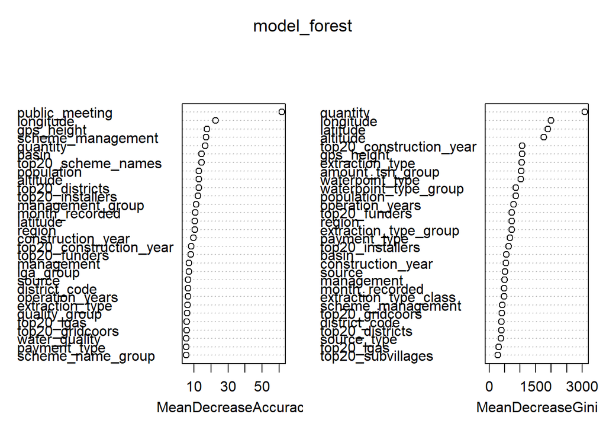

```r
varImpPlot(model_forest)
```

We remove the least important feature according to its MeanDecreaseAccuracy and run/remove features again and again until accuracy reaches a maximum.

Once we have the most important features, we can perform several Random Forest with different combinations of seeds (from 1 to 10), number of trees (100, 200 and 500) and node sizes (from 1 to 5) to see which combination performs better in terms of accuracy (total number of Random Forests: 150)

```r
forest <- function(seed, ntree, nodesize){
  set.seed(seed)
  model_forest <- randomForest(as.factor(status_group) ~ gps_height + longitude + latitude + basin + region + district_code + population + public_meeting + scheme_management + permit + construction_year + extraction_type + extraction_type_group + management_group + payment_type + water_quality + quality_group + quantity + source + source_type + waterpoint_type + funder_group + installer_group + altitude + scheme_name_group, data = training_data, ntree = ntree, nodesize = nodesize)

  pred_forest_train <- predict(model_forest, training_data)

  confmat <- confusionMatrix(pred_forest_train, training_data$status_group)

  new_line <- c(seed, ntree, nodesize, confmat$overall[1])
  results <- rbind(results, new_line, stringsAsFactors = FALSE)
}

results <- data.frame(matrix(ncol = 4, nrow = 0))

combs <- expand.grid(1:10, c(100, 200, 500), 1:5)
seedv <- combs[,1]
ntreev <- combs[,2]
nodesizev <- combs[,3]

result <- mapply(forest, seedv, ntreev, nodesizev)

df <- data.frame(matrix(unlist(result), nrow=150, byrow=T),stringsAsFactors=FALSE)
```

The highest accuracy is achieved with the following parameters: - seed: 6 - ntrees: 500 - nodesize: 1

```r
set.seed(6)

model_forest <- randomForest(as.factor(status_group) ~ gps_height + longitude + latitude + basin + region + district_code + population + public_meeting + scheme_management + permit + construction_year + extraction_type + extraction_type_group + management_group + payment_type + water_quality + quality_group + quantity + source + source_type + waterpoint_type + funder_group + installer_group + altitude + scheme_name_group, data = training_data, importance = TRUE, ntree = 500, nodesize = 1)

pred_forest_train <- predict(model_forest, training_data)

confusionMatrix(pred_forest_train, training_data$status_group)

randomForest::importance(model_forest)

varImpPlot(model_forest)
```

The accuracy for this Random Forest is 0.959.

We can now make the predictions on the test dataset and obtain the submission file.

```r
pred_forest_test <- predict(model_forest, test_data)

submission <- data.frame(test_data$id)
submission$status_group <- pred_forest_test
names(submission)[1] <- "id"

write.csv(submission, file = "submit.csv", row.names = FALSE)
```

With this Random Forest model, the score in the competition is 0.8178 (397th in ranking).

## Random Forest with Ranger package

This is another package to perform Random Forest algorithm. We have performed several Random Forest with different combinations of seeds (from 1 to 10) and number of trees (500, 1000 and 2000) to see which combination performs better in terms of accuracy (total number of Random Forests: 30). The highest accuracy is achieved with the following parameters: - seed: 10 - ntrees: 2000

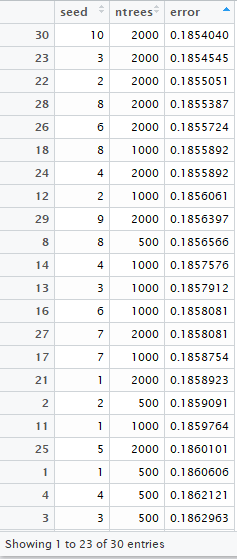

Errors for different combinations seed/ntrees

```r
set.seed(10)

model_ranger <- ranger(as.factor(status_group) ~ gps_height + longitude + latitude + basin + region + district_code + population + public_meeting + scheme_management + permit + construction_year + extraction_type + extraction_type_group + management_group + payment_type + water_quality + quality_group + quantity + source + source_type + waterpoint_type + funder_group + installer_group + altitude + scheme_name_group, data = training_data, importance = 'impurity', num.trees = 2000, respect.unordered.factors = "order")

pred_ranger_train <- predict(model_ranger, training_data)

importance(model_ranger)

pred_ranger_test <- predict(model_ranger, test_data)

submission <- data.frame(test_data$id)
submission$status_group <- pred_ranger_test$predictions
names(submission)[1] <- "id"

write.csv(submission, file = "submit.csv", row.names = FALSE)
```

Submitting this Random Forest with ranger package gives us a score of 0.8170 in the competition (a little bit worse than before)

## XGBoost

Here we run a XGBoost model with cross validation

```r
outcome <- "status_group"

vars <- colnames(total)

treatplan <- designTreatmentsZ(training_data, vars, verbose = FALSE)

newvars <- treatplan %>%
  use_series(scoreFrame) %>%
  filter(code %in% c("clean", "lev")) %>%
  use_series(varName)

training.treat <- prepare(treatplan, training_data,  varRestriction = newvars)

test.treat <- prepare(treatplan, test_data, varRestriction = newvars)

str(training.treat)
str(test.treat)

labels$status_group_num <- ifelse(labels$status_group == "non functional", 0, ifelse(labels$status_group == "functional needs repair", 1, 2))

# Cross validation
cv <- xgb.cv(data = as.matrix(training.treat),
            label = labels$status_group_num,
            nrounds = 400,
            nfold = 5,
            objective = "multi:softmax",
            num_class = 3,
            eta = 0.3,
            max_depth = 6,
            early_stopping_rounds = 10,
            verbose = 0
)

elog <- cv$evaluation_log

ntrees <- elog %>%
   summarize(ntrees.train = which.min(train_merror_mean),
             ntrees.test  = which.min(test_merror_mean))

ntrees <- ntrees$ntrees.test

# Xgboost
model_xgb <- xgboost(data = as.matrix(training.treat),
                   label = labels$status_group_num,
                   nrounds = ntrees,
                   objective = "multi:softmax",
                   num_class = 3,
                   eta = 0.3,
                   depth = 6,
                   verbose = 0
)

test_data$pred <- predict(model_xgb, as.matrix(test.treat))

test_data$status_group <- ifelse(test_data$pred == 0, "non functional", ifelse(test_data$pred == 1, "functional needs repair", "functional"))

submission <- data.frame(test_data$id)
submission$status_group <- test_data$status_group
names(submission)[1] <- "id"

write.csv(submission, file = "submit.csv", row.names = FALSE)
```

This XGBoost model gives us a score of 0.8131 in the competition (again a bit worse than before)

## Naïve Bayes

Here we run the Naïve Bayes classification model with all the features.

```r
test_data = cbind(test["id"], total[59401:74250,])

model_naive <- naiveBayes(status_group ~ ., data = training_data)

pred_naive <- predict(model_naive, test_data)
table(pred_naive)

submission <- data.frame(test_data$id)
submission$status_group <- pred_naive
names(submission)[1] <- "id"

write.csv(submission, file = "submit.csv", row.names = FALSE)
```

This Naïve Bayes model gives us a score of 0.5463 (extremely bad).

## H2O Random Forest

We use now H2O clusters to perform the Random Forest Algorithm.

```r
localH2O = h2o.init()

target = "status_group"
test_data = cbind(test["id"], total[59401:74250,])

trainHex = as.h2o(training_data, destination_frame = "train.hex")
testHex = as.h2o(test_data, destination_frame = "test.hex")

vars <- colnames(total)

rfHex = h2o.randomForest(
  x = vars,
  y = target,
  training_frame = trainHex,
  model_id = "rf_ntrees1000",
  ntrees = 1000,
  mtries = 10,
  seed = 1)

h2o.confusionMatrix(rfHex)

pred_h2orf = as.data.frame(h2o.predict(rfHex,testHex))[,1]

submission <- data.frame(test_data$id)
submission$status_group <- pred_h2orf
names(submission)[1] <- "id"

write.csv(submission, file = "submit.csv", row.names = FALSE)

h2o.shutdown(prompt = TRUE)
```

This H2O Random Forest model gives us a score of 0.8211 (255th in the rank).

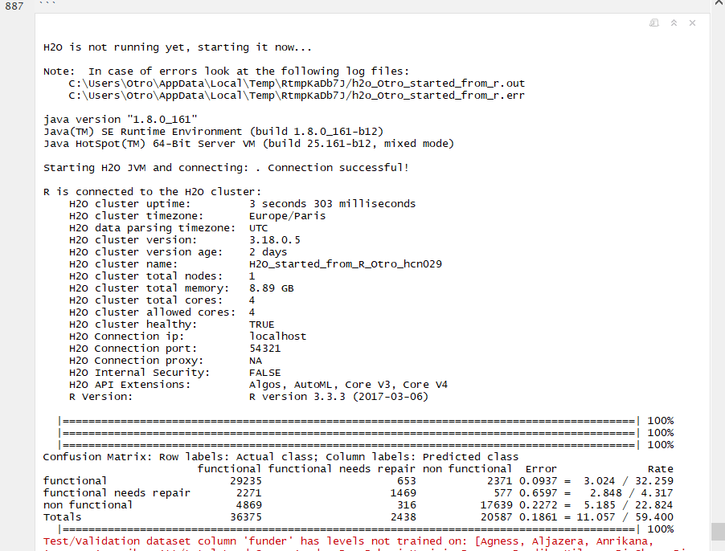

H2O Cluster information

## H2O Random Forest with cross validation

We run again the same model but with cross validation (nfold = 5).

```r
localH2O = h2o.init(min_mem_size='1G', max_mem_size='10G')

target = "status_group"
test_data = cbind(test["id"], total[59401:74250,])

trainHex = as.h2o(training_data, destination_frame = "train.hex")
testHex = as.h2o(test_data, destination_frame = "test.hex")

vars <- colnames(total)

rfHex = h2o.randomForest(
  x = vars,
  y = target,
  training_frame = trainHex,
  model_id = "rf_ntrees1000",
  ntrees = 1000,
  mtries = 10,
  seed = 1,
  nfolds = 5,
  stopping_rounds = 5)

h2o.confusionMatrix(rfHex)

pred_h2orf = as.data.frame(h2o.predict(rfHex,testHex))[,1]

submission <- data.frame(test_data$id)
submission$status_group <- pred_h2orf
names(submission)[1] <- "id"

write.csv(submission, file = "submit.csv", row.names = FALSE)

h2o.shutdown(prompt = TRUE)
```

This H2O Random Forest with cross-validation gives us a score of 0.8209 in the competition (slightly worse than before).